# Practical Machine Learning Project

dmendres

December 7, 2015

# Introduction

This document presents the results of the class project for Practical Machine Learning 7 Dec. 2015 version (predmachlearn-035).

## Data Loading, Cleaning and Exploratory Analysis

The documentation for the project data consists of a web page and a SIGCHI paper (http://groupware.les.inf.puc-rio.br/public/papers/2013.Velloso.QAR-WLE.pdf). The paper indicates that the measurements were made by three-axis acceleration, gyroscope and magnetometer sensors on each of the arm, glove (fore-arm) and belt of the user as well as on the dumbbell used in the exercise. The authors fit their model to aggregate variables over 2.5s time windows, but this data is valid in only a small percentage (2.07%) of the training data rows. Therefore, I will use the actual observations for prediction, not aggregated values.

We see the data is rather messy, with blank fields, fields indicating a divide by 0 error in the original spreadsheet, and actual NA values. After converting all of these to NA, the data columns load as integer, logical or numeric values. I will drop the pure logical columns, which indicate all NA values, the rows corresponding to window aggregate summaries (because as noted above the aggregate data are NA for all but these observations), remaining near-zero-variance predictors, and any remaining highly correlated variables. I eliminate from training the “context” columns giving user name, time stamps, row index, etc. As a side note, a quick look at the test data indicates that perfect performance could probably be obtained by fitting only to this context data (user and time stamp) since the test data appears to be rows extracted from the raw data. Of course, this *is not* the approach I have chosen as it would be counter to the spirit of the problem!

For model development, I partitioned the data into subsets with 75% for training and 25% for cross validation.

The aggregate values summed in each 2.5s window are flagged by new_window == “yes”. These are the only rows with non-NA values for the “aggregate” variables such as max, min, avg, var, stddev, etc. Therefore, I am going to delete the new window rows from the training data, but of course, no observations will be deleted from the validation or test data! I removed the observation context columns from all data sets since these are not valid predictors.

Then I analyze the remainder of the observation variables for those which have only NA values and remove them from training, validation, and test data sets.

There are no remaining “near zero variance” predictors, as defined by the caret nzvPredictors function. However, we do find some correlated predictors, and remove them.

```
## [1] "Remove high correlation predictors"
```

```
## [1] "accel_belt_z"     "roll_belt"        "accel_belt_y"
## [4] "accel_belt_x"     "gyros_dumbbell_x" "gyros_dumbbell_z"
## [7] "gyros_arm_x"
```

The predictors are then pre-processed to scale and center the values. The same preprocessing object, derived from the training data, must be used to preprocess the training, validation, and test data sets.

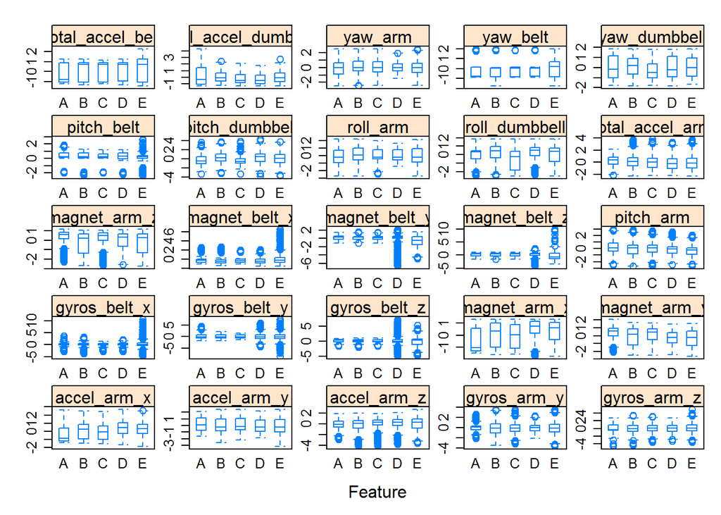

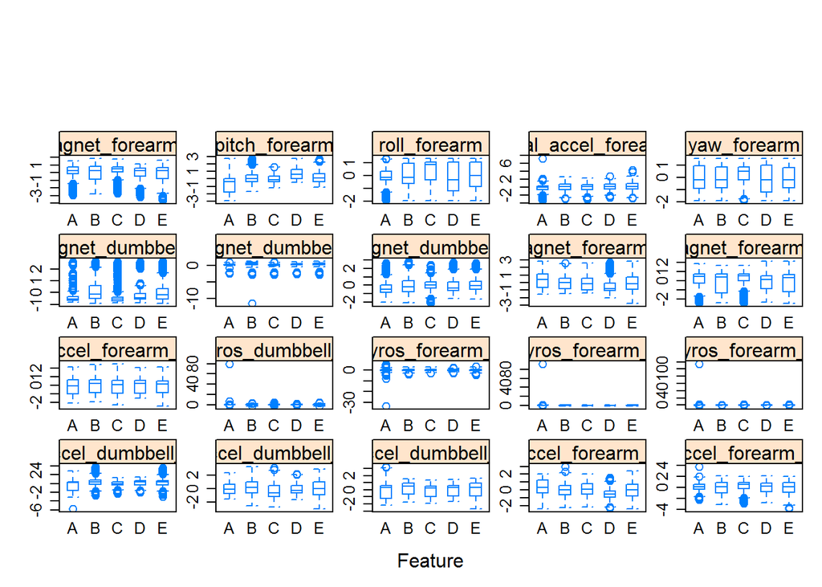

Observing the box plots of the remining scaled and centered features, we don’t have a strong preference for any of them over the others as many of the features appear to aid in distinguishing the 5 classes of exercise.

# Model Fitting

The resulting model (modelFit) is displayed, along with the top 20 (ranked) predictors. We display the validation confusion matrix (predicted vs. known classe results in the validation data set):

```
## Random Forest
##
## 14408 samples
##    45 predictor
##     5 classes: 'A', 'B', 'C', 'D', 'E'
##
## No pre-processing
## Resampling: Cross-Validated (10 fold)
## Summary of sample sizes: 1439, 1440, 1440, 1443, 1440, 1441, ...
## Resampling results across tuning parameters:
##
##   mtry  Accuracy   Kappa      Accuracy SD  Kappa SD
##    2    0.9217719  0.9009164  0.005755136  0.007305164
##   23    0.9299310  0.9112706  0.006193368  0.007838789
##   45    0.9236458  0.9033243  0.006117771  0.007747145
##
## Accuracy was used to select the optimal model using  the largest value.
## The final value used for the model was mtry = 23.
```

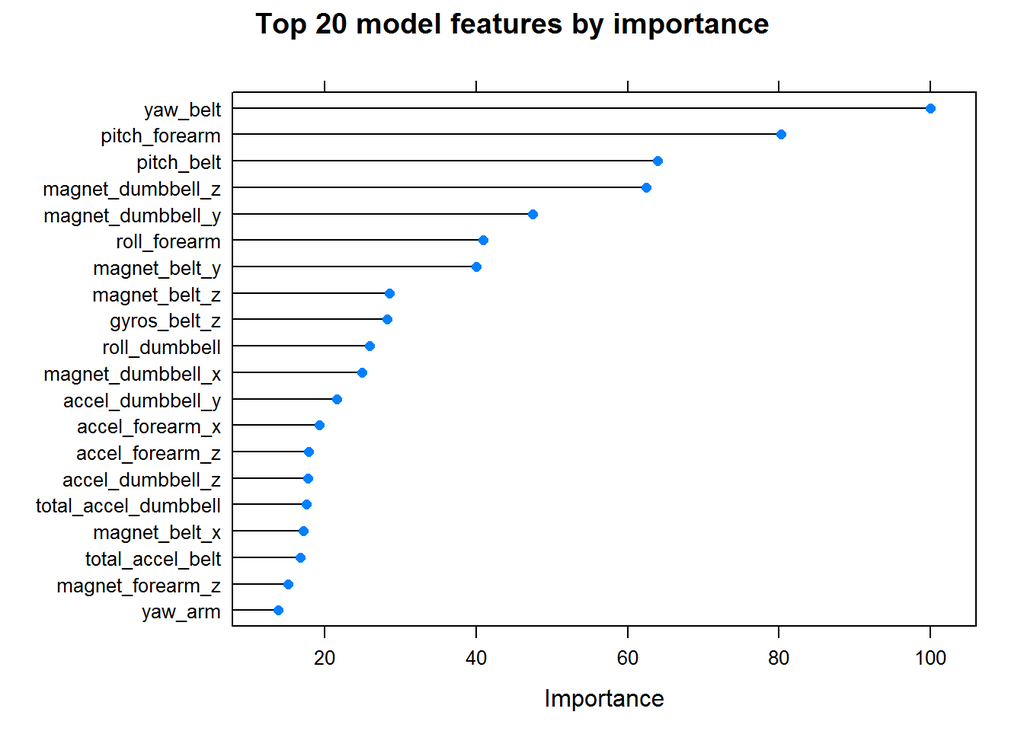

```
## Confusion Matrix and Statistics
##
##
## validationPredictors    A    B    C    D    E
##                    A 1393    9    0    0    0
##                    B    2  937    2    0    0
##                    C    0    3  850    6    2
##                    D    0    0    3  798    4
##                    E    0    0    0    0  895
##
## Overall Statistics
##
##                Accuracy : 0.9937
##                  95% CI : (0.991, 0.9957)
##     No Information Rate : 0.2845
##     P-Value [Acc > NIR] : < 2.2e-16
##
##                   Kappa : 0.992
##  Mcnemar's Test P-Value : NA
##
## Statistics by Class:
##
##                      Class: A Class: B Class: C Class: D Class: E
## Sensitivity            0.9986   0.9874   0.9942   0.9925   0.9933
## Specificity            0.9974   0.9990   0.9973   0.9983   1.0000
## Pos Pred Value         0.9936   0.9957   0.9872   0.9913   1.0000
## Neg Pred Value         0.9994   0.9970   0.9988   0.9985   0.9985
## Prevalence             0.2845   0.1935   0.1743   0.1639   0.1837
## Detection Rate         0.2841   0.1911   0.1733   0.1627   0.1825
## Detection Prevalence   0.2859   0.1919   0.1756   0.1642   0.1825
## Balanced Accuracy      0.9980   0.9932   0.9957   0.9954   0.9967
```

This result gives us an 88.1% probability of success on all of the 20 test problems. As a closing note, I observed that all of my submitted test data cases validated.